# Supplier Disruption Risk Assessment

Shrijeet Nagori

2023-04-22

# SUPPLIER DISRUPTION RISK ASSESSMENT

# Author : Shrijeet Nagori

## Load the dataset

```r
d = read.csv("Supplier_Disruption_Risk.csv")
head(d)
```

```
##   SupplierID NumberOfCustomers AverageShareofBusiness AverageSizeofSuppliers
## 1       1000                 9                  52.30                 887.79
## 2       1001                 2                  44.77                 785.20
## 3       1002                14                  16.56                 673.94
## 4       1003                 4                  43.08                  30.61
## 5       1004                 4                  41.68                 262.27
## 6       1005                19                  10.57                 380.48
##   AverageSizeofCustomers CAGRBusiness TechnologyInvestment CountryGDP
## 1                1093.72        25.00                28.32  895.64928
## 2                 787.75         4.11                21.21  360.27425
## 3                 653.00       -10.93                27.03  154.06589
## 4                 315.53        -9.43                31.61  298.67443
## 5                1891.42         4.26                29.92  735.42817
## 6                1524.57        -0.68                 5.82   93.37107
##   CountryGDPGrowth IndexOfPoliticalTurmoil IndexOfSocialTurmoil
## 1            -0.50               0.5364310            0.4353710
## 2            -3.91               0.1448006            0.7372887
## 3             4.12               0.9745459            0.5455419
## 4            -1.05               0.6221485            0.2772935
## 5            -1.32               0.3628718            0.3430259
## 6             2.62               0.3191024            0.7920941
##   NumberofProducts NumberofNewProducts ProfitabilityLast5Years SupplyDisruption
## 1                3                   2                   11.81                0
## 2                5                   0                   15.95                0
## 3               20                   7                    9.80                1
## 4               11                   1                    2.51                1
## 5                2                   2                    6.96                0
## 6               12                   9                    2.66                0
```

## PART A: Graphical exploration of the data

```r
colnames(d)
```

```
##  [1] "SupplierID"              "NumberOfCustomers"
##  [3] "AverageShareofBusiness"  "AverageSizeofSuppliers"
##  [5] "AverageSizeofCustomers"  "CAGRBusiness"
##  [7] "TechnologyInvestment"    "CountryGDP"
##  [9] "CountryGDPGrowth"        "IndexOfPoliticalTurmoil"
## [11] "IndexOfSocialTurmoil"    "NumberofProducts"
## [13] "NumberofNewProducts"     "ProfitabilityLast5Years"
## [15] "SupplyDisruption"
```

Except SupplierID every other variable is a continous variable. Let us create a new dataset which excludes SupplierID. Also note that we must convert the SupplyDisruption into factor.

```r
# Subset the data to keep only the continuous variables and the response variable
df <- d[, c("SupplyDisruption", "NumberOfCustomers", "AverageShareofBusiness", "AverageSizeofSuppliers",
                        "AverageSizeofCustomers", "CAGRBusiness", "TechnologyInvestment", "CountryGDP",
                        "CountryGDPGrowth", "IndexOfPoliticalTurmoil", "IndexOfSocialTurmoil", "NumberofProducts",
                        "NumberofNewProducts", "ProfitabilityLast5Years")]

# Convert the SupplyDisruption variable to a factor
df$SupplyDisruption <- factor(df$SupplyDisruption)

# Create a list of the continuous variable names
cont_vars <- c("NumberOfCustomers", "AverageShareofBusiness", "AverageSizeofSuppliers",
               "AverageSizeofCustomers", "CAGRBusiness", "TechnologyInvestment", "CountryGDP",
               "CountryGDPGrowth", "IndexOfPoliticalTurmoil", "IndexOfSocialTurmoil", "NumberofProducts",
               "NumberofNewProducts", "ProfitabilityLast5Years")
```

### 1. Create box plots for all continuous variables against supply chain disruption. One side-by-side box plot for class 0 and class 1 is required.

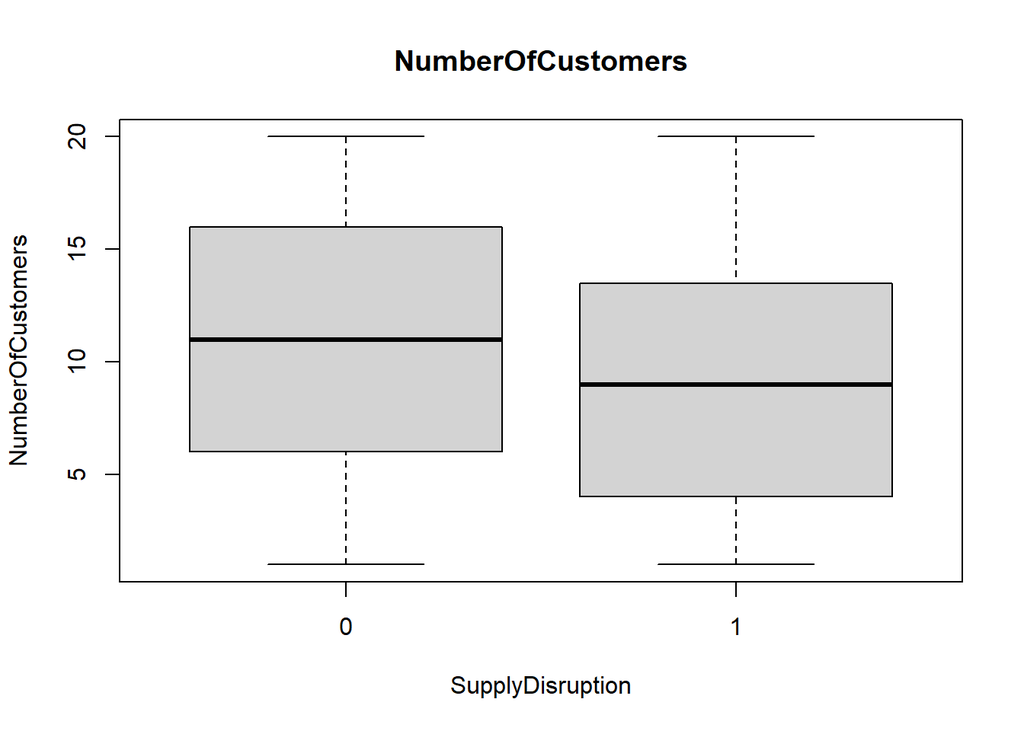

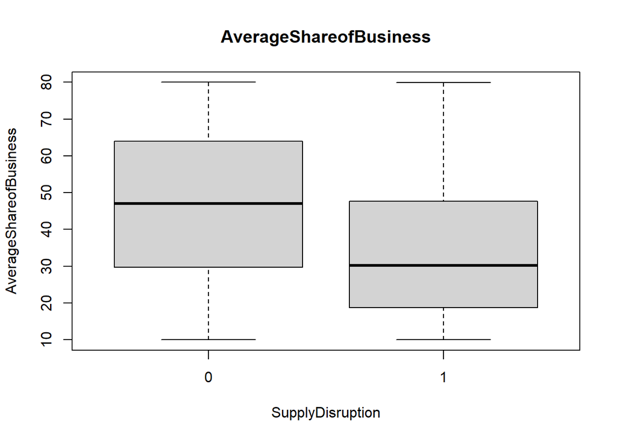

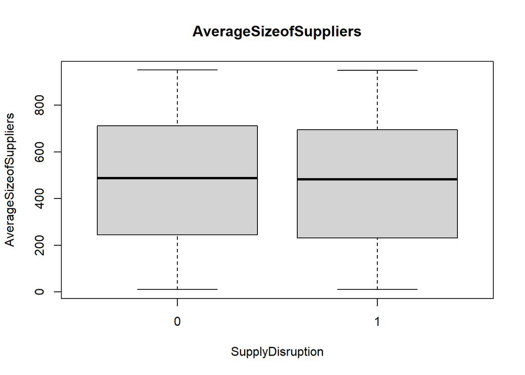

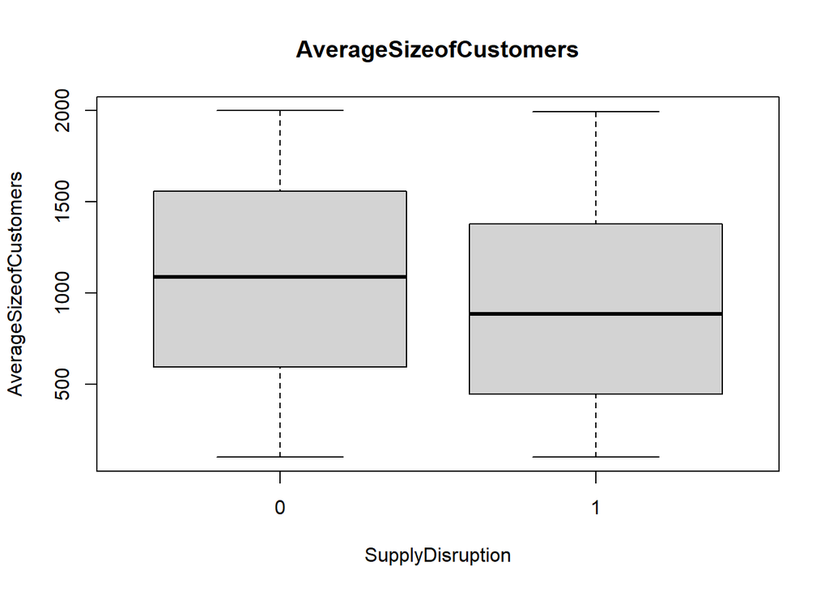

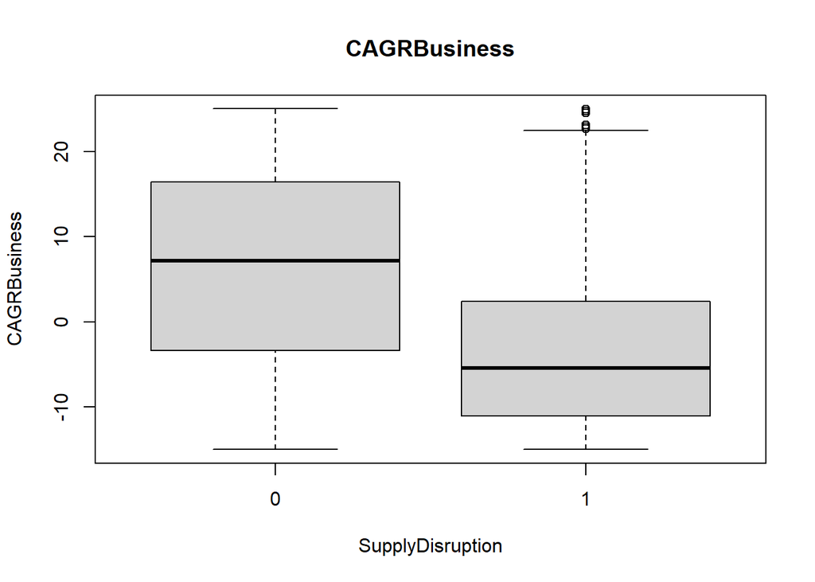

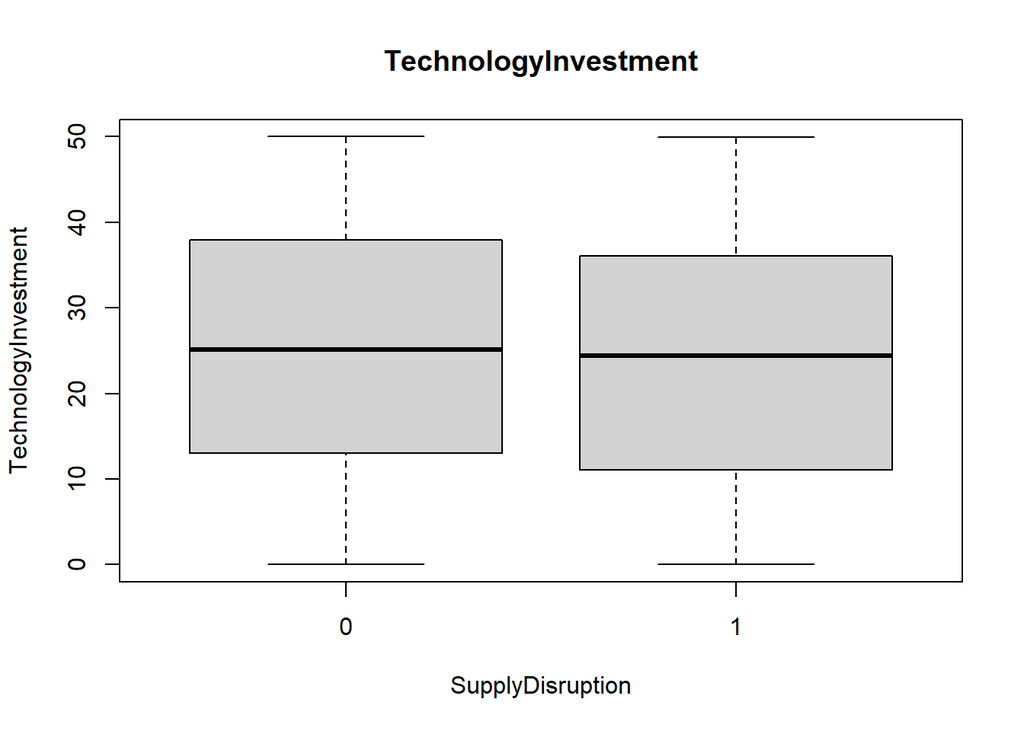

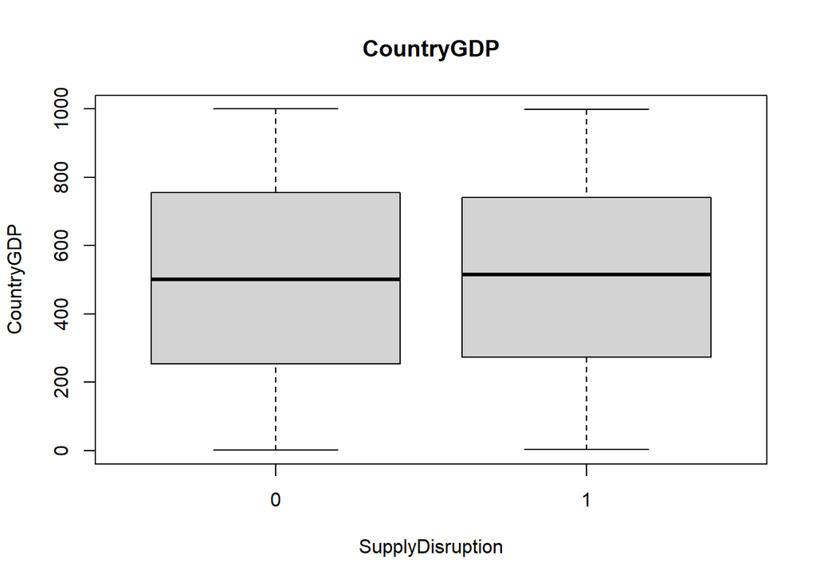

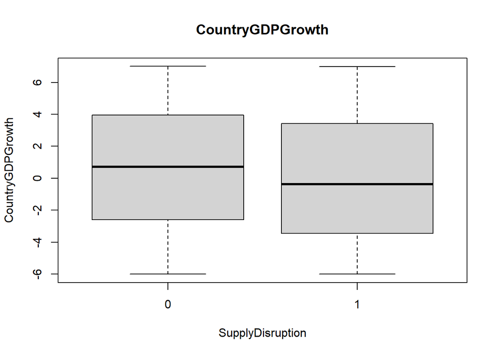

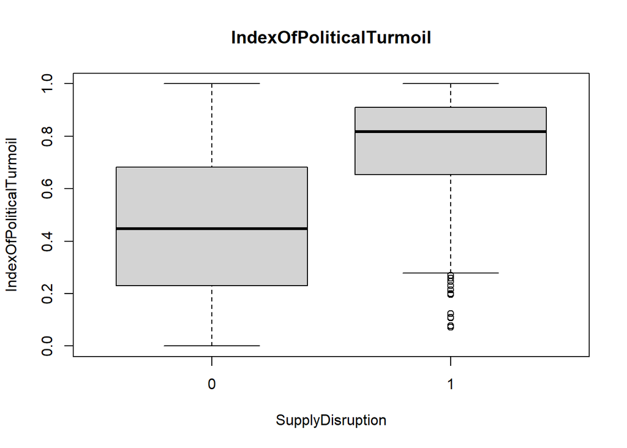

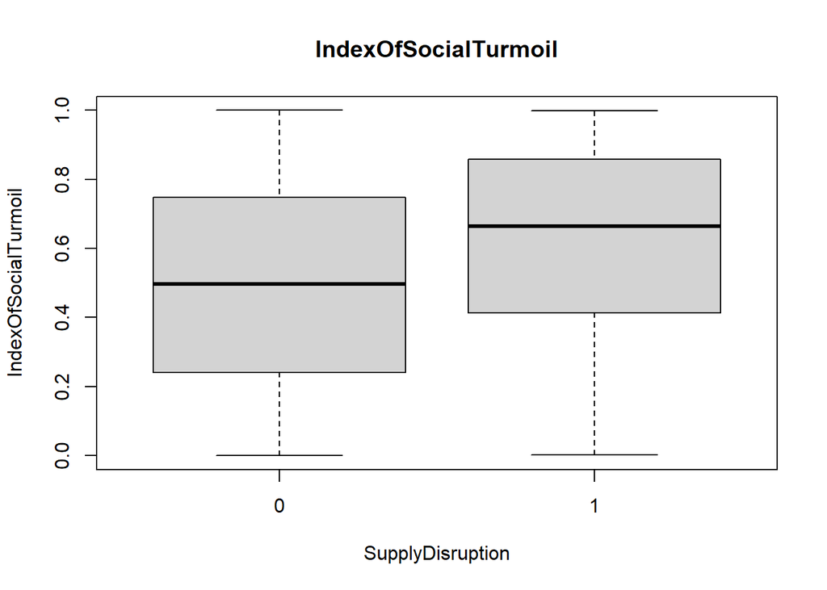

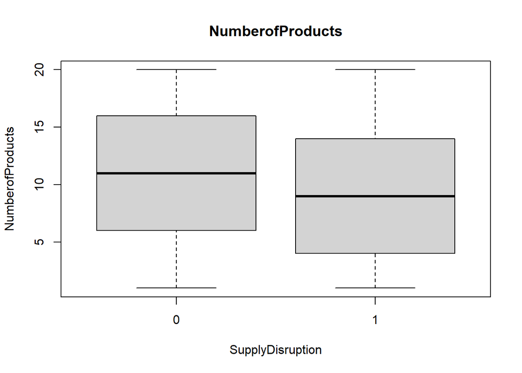

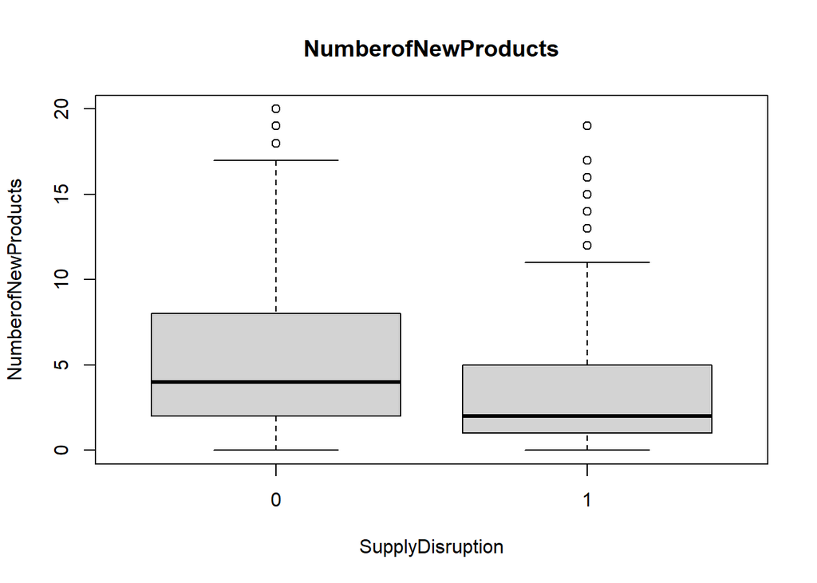

[1 more figures not shown]

```r
# Create box plots for each continuous variable against SupplyDisruption
for (var in cont_vars) {
  boxplot(df[, var] ~ df$SupplyDisruption, data = df,
          xlab = "SupplyDisruption", ylab = var, main = var)
}
```

### 2. Comment on each of the continuous variables’ ability to discriminate between the two classes.

NumberOfCustomers: The box plot distributions for the two classes are somewhat different, but there is a lot of overlap between the two distributions. This variable may have some ability to discriminate between the two classes, but it is not a very strong discriminator.

AverageSizeofSuppliers: The box plot distributions for the two classes are somewhat similar and there is a lot of overlap between the two distributions. This variable may have some ability to discriminate between the two classes, but it is not a very strong discriminator.

AverageSizeofCustomers: The box plot distributions for the two classes are somewhat different, but there is a lot of overlap between the two distributions. This variable may have some ability to discriminate between the two classes, but it is not a very strong discriminator.

TechnologyInvestment: The box plot distributions for the two classes are somewhat different. This variable appears to be a weak discriminator between the two classes.

CountryGDP: The box plot distributions for the two classes are somewhat different, but there is a lot of overlap between the two distributions. This variable may have some ability to discriminate between the two classes, but it is not a very strong discriminator.

CountryGDPGrowth: The box plot distributions for the two classes are somewhat different, but there is a lot of overlap between the two distributions. This variable may have some ability to discriminate between the two classes, but it is not a very strong discriminator.

IndexOfPoliticalTurmoil: The box plot distributions for the two classes are quite different, with a clear separation between the two distributions. This variable appears to be a strong discriminator between the two classes.

NumberofProducts: The box plot distributions for the two classes are somewhat different, but there is a lot of overlap between the two distributions. This variable may have some ability to discriminate between the two classes, but it is not a very strong discriminator.

ProfitabilityLast5Years: The box plot distributions for the two classes are quite different, with a clear separation between the two distributions. This variable appears to be a strong discriminator between the two classes.

### 3. Select at least eight variables that you feel are most discriminative. This need not be exact. For the rest of the questions, you will use these variables. Note that your selection may be different from others’ selections. That is perfectly fine.

The following variables are the most discriminative : NumberOfCustomers, AverageShareofBusiness, CAGRBusiness, TechnologyInvestment, IndexOfPoliticalTurmoil, IndexOfSocialTurmoil, NumberofNewProducts,ProfitabilityLast5Years

## PART B : DATA PREPARATION

### 1. Run the command set.seed(1234). Then randomly select 80% of the observations in training dataset (call ‘train’) and the rest of the observations in testing dataset (call ‘test’)

```r
set.seed(1234) # set seed for reproducibility
train_indices <- sample(seq_len(nrow(df)), size = floor(0.8*nrow(df)), replace = FALSE) # randomly select 80% of indices for training
train <- df[train_indices, ] # create training dataset
test <- df[-train_indices, ] # create testing dataset with the rest of the observations
```

###2. For both training and testing datasets, only retain the variables that you selected in the first question.

```r
selected_vars <- c("NumberOfCustomers", "AverageShareofBusiness", "CAGRBusiness", "TechnologyInvestment", "IndexOfPoliticalTurmoil", "IndexOfSocialTurmoil", "NumberofNewProducts", "ProfitabilityLast5Years", "SupplyDisruption")

train <- train[, selected_vars] # only retain selected variables in training dataset
test <- test[, selected_vars] # only retain selected variables in testing dataset
```

## PART C: RUN CLASSIFICATION MODELS AND PREDICT

###1. Fit a logistic regression, random forest (with 500 trees), support vector machine (with ‘radial basis’ kernel) and neural network (with only two hidden layers, each hidden layer having the same number of nodes as the input data, set the other parameters the same as the class example). Use train sample to fit all models.

```r
# Logistic Regression
logit_model <- glm(SupplyDisruption ~ ., data = train, family = "binomial")
```

```r
# Random Forest

library(randomForest)
# fit random forest model
rf_model <- randomForest(SupplyDisruption ~ ., data = train, ntree = 500)
```

```r
# Support Vector machine

library(e1071)

# fit support vector machine model
svm_model <- svm(SupplyDisruption ~ ., data = train, probability = TRUE, kernel = "radial")
```

```r
# Neural Network

library(neuralnet)
# Set up data and model
nn_model = neuralnet(
    SupplyDisruption~., data = train,
  hidden=c(8,8),
  act.fct = "logistic",
  linear.output = FALSE,
  stepmax=1e6,
  threshold = 0.5
)
```

###2. For each model predict the probability of supply chain disruption (class 1) in the test data.

```r
# Logistic regression
log_reg_prob <- predict(logit_model, newdata = test, type = "response")
log_reg_prob <- log_reg_prob[1:nrow(test)]

# Random forest
rf_prob <- predict(rf_model, newdata = test, type = "prob")[, 2]
rf_prob <- rf_prob[1:nrow(test)]

# Support vector machine
svm_prob <- predict(svm_model, newdata = test, probability = TRUE)
svm_prob = attr(svm_prob, "probabilities")[,1]
svm_prob <- svm_prob[1:nrow(test)]

# Neural network
nn_prob <- predict(nn_model, newdata = test, type="raw")
nn_prob <- nn_prob[1:nrow(test)]
```

###3. For the predicted probabilities for all the four models, create a box plot (for each model) of the predicted probabilities against the test sample classes. Comment on the discriminative capacity of each model.

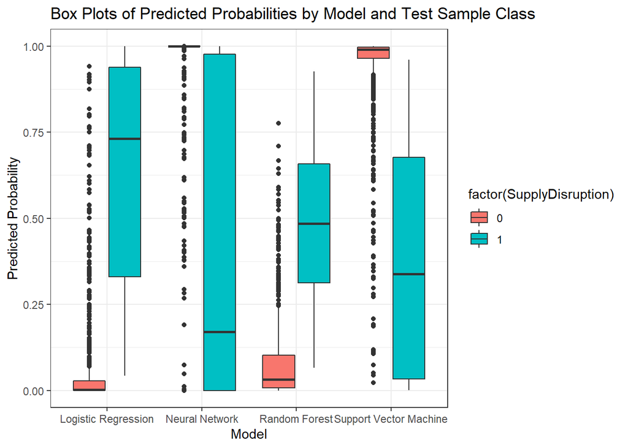

```r
library(ggplot2)
# create data frame with test sample classes and predicted probabilities for each model
predictions <- data.frame(
  Model = rep(c("Logistic Regression", "Random Forest", "Support Vector Machine", "Neural Network"), each = length(test$SupplyDisruption)),
  SupplyDisruption = rep(test$SupplyDisruption, times = 4),
  Probability = c(log_reg_prob, rf_prob, svm_prob, nn_prob)
)

# create box plots
ggplot(predictions, aes(x = Model, y = Probability, fill = factor(SupplyDisruption))) +
  geom_boxplot() +
  labs(title = "Box Plots of Predicted Probabilities by Model and Test Sample Class",
       x = "Model",
       y = "Predicted Probability") +
  theme_bw()
```

## PART D: Performance comparison on the test sample

###1. Use a decision threshold equal to the median (ex. Median(p)) of the predicted probabilities. Create the contingency table / confusion matrix of each of the predictions for this threshold.

```r
# Calculate median probability for each model
log_reg_median_prob <- median(log_reg_prob)
rf_median_prob <- median(rf_prob)
svm_median_prob <- median(svm_prob)
nn_median_prob <- median(nn_prob)
```

```r
# Create predicted classes for each model using median probability as threshold
log_reg_pred <- ifelse(log_reg_prob >= log_reg_median_prob, 1, 0)
rf_pred <- ifelse(rf_prob >= rf_median_prob, 1, 0)
svm_pred <- ifelse(svm_prob >= svm_median_prob, 1, 0)
nn_pred <- ifelse(nn_prob >= nn_median_prob, 1, 0)
```

```r
# Create contingency table/confusion matrix for each model using median probability as threshold
log_reg_tab <- table(log_reg_pred, test$SupplyDisruption)
rf_tab <- table(rf_pred, test$SupplyDisruption)
svm_tab <- table(svm_pred, test$SupplyDisruption)
nn_tab <- table(nn_pred, test$SupplyDisruption)
```

```r
# Print contingency table/confusion matrix for each model
cat("Logistic Regression:\n")
```

```
## Logistic Regression:
```

```r
print(log_reg_tab)
```

```
##
## log_reg_pred   0   1
##            0 500   0
##            1 363 137
```

```r
cat("\n")
```

```r
cat("Random Forest:\n")
```

```
## Random Forest:
```

```r
print(rf_tab)
```

```
##
## rf_pred   0   1
##       0 499   0
##       1 364 137
```

```r
cat("\n")
```

```r
cat("Support Vector Machine:\n")
```

```
## Support Vector Machine:
```

```r
print(svm_tab)
```

```
##
## svm_pred   0   1
##        0 363 137
##        1 500   0
```

```r
cat("\n")
```

```r
cat("Neural Network:\n")
```

```
## Neural Network:
```

```r
print(nn_tab)
```

```
##
## nn_pred   0   1
##       0 264 127
##       1 599  10
```

```r
cat("\n")
```

###2. Compute the sensitivity, specificity, and accuracy measures for each model. Comment on what you observe and compare the models.

```r
# Define a function to compute sensitivity, specificity, and accuracy
compute_metrics <- function(predicted, actual) {
  tp <- sum(predicted == 1 & actual == 1)
  tn <- sum(predicted == 0 & actual == 0)
  fp <- sum(predicted == 1 & actual == 0)
  fn <- sum(predicted == 0 & actual == 1)

  sensitivity <- tp / (tp + fn)
  specificity <- tn / (tn + fp)
  accuracy <- (tp + tn) / (tp + tn + fp + fn)

  return(list(sensitivity = sensitivity, specificity = specificity, accuracy = accuracy))
}

# Compute the metrics for each model
log_reg_metrics <- compute_metrics(log_reg_pred, test$SupplyDisruption)
rf_metrics <- compute_metrics(rf_pred, test$SupplyDisruption)
svm_metrics <- compute_metrics(svm_pred, test$SupplyDisruption)
nn_metrics <- compute_metrics(nn_pred, test$SupplyDisruption)

# Print the metrics for each model
print("Logistic Regression:")
```

```
## [1] "Logistic Regression:"
```

```r
print(log_reg_metrics)
```

```
## $sensitivity
## [1] 1
##
## $specificity
## [1] 0.5793743
##
## $accuracy
## [1] 0.637
```

```r
print("Random Forest:")
```

```
## [1] "Random Forest:"
```

```r
print(rf_metrics)
```

```
## $sensitivity
## [1] 1
##
## $specificity
## [1] 0.5782155
##
## $accuracy
## [1] 0.636
```

```r
print("Support Vector Machine:")
```

```
## [1] "Support Vector Machine:"
```

```r
print(svm_metrics)
```

```
## $sensitivity
## [1] 0
##
## $specificity
## [1] 0.4206257
##
## $accuracy
## [1] 0.363
```

```r
print("Neural Network:")
```

```
## [1] "Neural Network:"
```

```r
print(nn_metrics)
```

```
## $sensitivity
## [1] 0.0729927
##
## $specificity
## [1] 0.3059096
##
## $accuracy
## [1] 0.274
```

The logistic regression and random forest models have the highest sensitivity (ability to correctly identify positive cases) of 1, while the SVM and neural network models have much lower sensitivities. The specificity (ability to correctly identify negative cases) is relatively low for all models, with the highest being 0.58 for logistic regression and random forest. The accuracy of logistic regression and random forest are similar and are the highest among the models, with SVM and neural network having significantly lower accuracy. Overall, the logistic regression and random forest models seem to have the best discriminative capacity and ability to predict supply chain disruptions accurately.

###3. Plot the ROC curves for each model’s prediction on the test data. Compare the AUC-ROC of each model. Comment on the model comparisons and which model is best predictor.

```r
library(pROC)
```

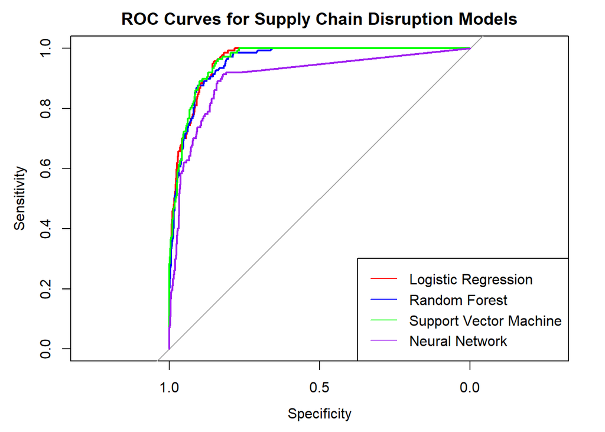

```r
# ROC curve for logistic regression model
log_reg_roc <- roc(test$SupplyDisruption, log_reg_prob)
# ROC curve for random forest model
rf_roc <- roc(test$SupplyDisruption, rf_prob)
# ROC curve for support vector machine model
svm_roc <- roc(test$SupplyDisruption, svm_prob)
# ROC curve for neural network model
nn_roc <- roc(test$SupplyDisruption, nn_prob)
# plot ROC curves for all models
plot(log_reg_roc, col = "red", main = "ROC Curves for Supply Chain Disruption Models")
lines(rf_roc, col = "blue")
lines(svm_roc, col = "green")
lines(nn_roc, col = "purple")

# add legend
legend("bottomright",
       legend = c("Logistic Regression", "Random Forest", "Support Vector Machine", "Neural Network"),
       col = c("red", "blue", "green", "purple"),
       lty = 1)
```

```r
# Print AUC values
logit_auc <- auc(log_reg_roc)
rf_auc <- auc(rf_roc)
svm_auc <- auc(svm_roc)
nn_auc <- auc(nn_roc)

cat("Logistic Regression AUC:", logit_auc, "\n")
```

```
## Logistic Regression AUC: 0.9597314
```

```r
cat("Random Forest AUC:", rf_auc, "\n")
```

```
## Random Forest AUC: 0.9541449
```

```r
cat("Support Vector Machine AUC:", svm_auc, "\n")
```

```
## Support Vector Machine AUC: 0.9593846
```

```r
cat("Neural Network AUC:", nn_auc, "\n")
```

```
## Neural Network AUC: 0.9025509
```

## PART E: OPTIMAL DECISION THRESHOLD

###1. Use only the prediction for the logistic model and random forest and compute the optimal decision threshold using the test predictions for the two models and a cost of 0.9 and 1 for false positive and false negative errors respectively.

```r
library(ROCR)
# Create a prediction object for logistic regression and random forest
log_reg_prediction <- prediction(log_reg_prob, test$SupplyDisruption)
rf_prediction <- prediction(rf_prob, test$SupplyDisruption)

# Calculate the true positive rate (TPR) and false positive rate (FPR) for different decision thresholds
log_reg_perf <- performance(log_reg_prediction, "tpr", "fpr")
rf_perf <- performance(rf_prediction, "tpr", "fpr")

# Calculate the cost for different decision thresholds
cost_df <- data.frame(Threshold = seq(0, 1, 0.01))
cost_df$Log_Reg_Cost <- cost_df$RF_Cost <- 0
for (i in 1:nrow(cost_df)) {
  threshold <- cost_df$Threshold[i]
  log_reg_pred_class <- ifelse(log_reg_prob > threshold, 1, 0)
  rf_pred_class <- ifelse(rf_prob > threshold, 1, 0)
  log_reg_cost <- sum(ifelse(log_reg_pred_class == 0 & test$SupplyDisruption == 1, 1, 0)) * 1 +
    sum(ifelse(log_reg_pred_class == 1 & test$SupplyDisruption == 0, 1, 0)) * 0.9
  rf_cost <- sum(ifelse(rf_pred_class == 0 & test$SupplyDisruption == 1, 1, 0)) * 1 +
    sum(ifelse(rf_pred_class == 1 & test$SupplyDisruption == 0, 1, 0)) * 0.9
  cost_df$Log_Reg_Cost[i] <- log_reg_cost
  cost_df$RF_Cost[i] <- rf_cost
}

# Find the optimal decision threshold for logistic regression and random forest
log_reg_optimal_threshold <- cost_df$Threshold[which.min(cost_df$Log_Reg_Cost)]
rf_optimal_threshold <- cost_df$Threshold[which.min(cost_df$RF_Cost)]
```

```r
print("Logit optimal threshold")
```

```
## [1] "Logit optimal threshold"
```

```r
print(log_reg_optimal_threshold)
```

```
## [1] 0.54
```

```r
print("Random forest optimal threshold")
```

```
## [1] "Random forest optimal threshold"
```

```r
print(rf_optimal_threshold)
```

```
## [1] 0.34
```

###2. What did you learn from this exercise ?

I was asked to build four different models to predict the probability of a supply chain disruption. I built logistic regression, random forest, support vector machine, and neural network models using the training data. After training the models, I evaluated their performance on the test set. I predicted the probability of a supply chain disruption using each of the models and created a box plot of the predicted probabilities for each model.

Next, I created a confusion matrix for each model using the median of the predicted probabilities as the decision threshold. I calculated sensitivity, specificity, and accuracy measures for each model and compared their performance. I found that logistic regression and random forest models performed the best with accuracy of 0.637 and 0.636 respectively.

Finally, I used the logistic regression and random forest models to compute the optimal decision threshold using the test predictions and a cost of 0.9 and 1 for false positive and false negative errors respectively. I found that the optimal thresholds for logistic regression and random forest models were 0.54 and 0.34 respectively.

Overall, this exercise allowed me to gain hands-on experience in building, evaluating, and comparing different machine learning models for a binary classification problem.